# Event Studies and Fama–MacBeth

Data Analytics for Finance

Caspar David Peter

peter@rsm.nl

Rotterdam School of Management, Accounting Department

# Event Studies and Fama–MacBeth

## Before We Start…

### Assignment Release and Submission Schedule

| Assignment | Release | Deadline | Graded |
| --- | --- | --- | --- |
| A1 | 11.02.2026 | 25.02.2026 | $\checkmark$ |
| A2 | 11.02.2026 | 25.02.2026 | $\checkmark$ |
| A3 | 18.02.2026 | 04.03.2026 |  |
| A4 | 25.02.2026 | 11.03.2026 |  |
| A5 | **04.03.2026** | **18.03.2026** |  |
| A6 | 11.03.2026 | 25.03.2026 |  |

**Assignment 5 Is Out!**

A5 asks you to implement a full event study on the Dieselgate data. Everything we cover today is directly relevant. Deadline: **March 18, 2026**.

## Overview

### Where we are in the research pipeline

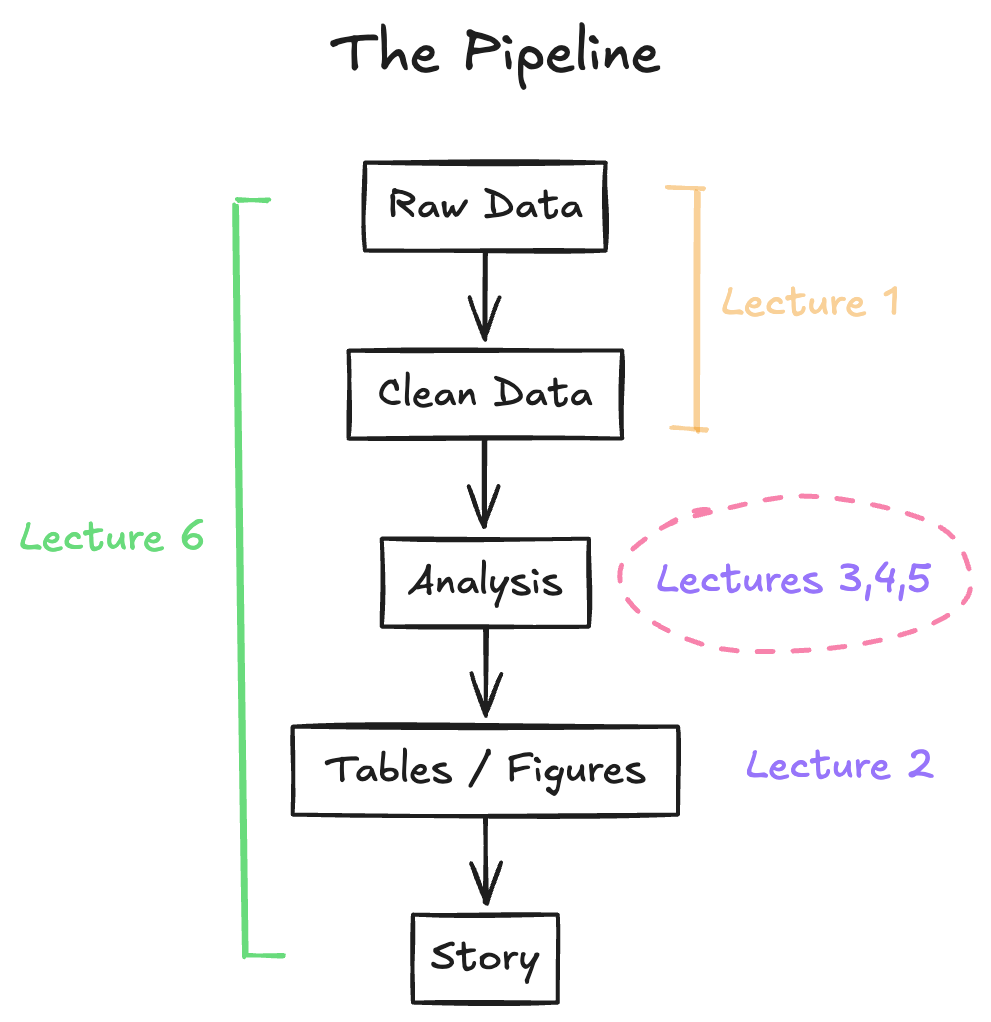

Today we add two specialized tools for finance research: **event studies** for measuring market reactions to specific events, and **Fama–MacBeth regressions** for testing whether firm characteristics systematically predict returns over time.

## Overview

### Today’s learning objectives

- Understand the logic of event studies as a **causal inference** tool for measuring stock price reactions
- Define estimation and event windows, estimate expected return models, and calculate **cumulative abnormal returns (CARs)**
- Compare the **Market Model** and **Fama–French 3-Factor Model** as benchmarks for expected returns
- Understand the **Fama–MacBeth** two-step procedure for cross-sectional asset pricing tests
- Recognize when to use event studies vs. Fama–MacBeth vs. the panel methods from L4
- Appreciate recent methodological advances connecting event studies to causal inference

# From DiD to Event Studies

## From DiD to Event Studies

### What’s new, what’s familiar

#### What you already know (L3–L4)

- OLS identifies cross-sectional relationships
- DiD exploits within-group variation over time
- Both ask: “What would have happened **without** the treatment?”
- The parallel trends assumption provides the counterfactual in DiD

#### What’s new today

- Event studies ask the **same counterfactual question**, but at daily frequency and for specific corporate or market events
- The “counterfactual” is now the **expected return** from a factor model, not a parallel trend from a control group
- Short event windows (days, not months/years) help with identification

## From DiD to Event Studies

### When to use what

| Method | Best for | Identification | Time scale |
| --- | --- | --- | --- |
| OLS (L3) | Cross-sectional relationships | Controls + research design | Cross-section |
| DiD / Panel FE (L4) | Policy changes, treatment rollouts | Parallel trends + FE | Months–years |
| **Event study (L5)** | Market reactions to specific events | Market efficiency + factor model | Days |
| **Fama–MacBeth (L5)** | Systematic return predictability | Repeated cross-sections | Months–years |

Each method makes different **assumptions** to construct the counterfactual. No single method dominates — the right choice depends on the research question and data structure.

## From DiD to Event Studies

### Why event studies work — The efficient market hypothesis

Event studies rely on a version of the **semi-strong form** of market efficiency (Fama 1970):

> Stock prices quickly incorporate all publicly available information. When new information arrives, prices adjust rapidly — abnormal returns are concentrated in a short window around the event.

**Identification assumption**

The event study identification assumption is analogous to parallel trends in DiD. In DiD we assume: *absent treatment, treated and control groups would have followed the same trend*. In event studies we assume: *absent the event, the stock would have earned its expected return from the factor model*.

## From DiD to Event Studies

### Our research question

> **“What was the stock market reaction to the Dieselgate scandal announcement on September 18, 2015?”**

On this date, the U.S. Environmental Protection Agency (EPA) issued a Notice of Violation to Volkswagen for using illegal “defeat devices” in diesel engines. The question is whether — and how much — investors punished German automakers relative to non-German competitors.

#### Roadmap: Five steps to an event study

1. **Define** the event and time windows
2. **Estimate** a model of expected returns (Market Model or FF3)
3. **Calculate** abnormal returns (AR = actual − expected)
4. **Aggregate** abnormal returns into cumulative abnormal returns (CAR)
5. **Test** whether CARs are statistically and economically significant

# Event Study Methodology

## Event Study Methodology

### Step 1: Define the event

#### Event date: September 18, 2015

- EPA issues Notice of Violation — a public, well-dated, exogenous shock
- This is what makes Dieselgate a clean event: clear date, public information, limited anticipation

#### What makes a “good” event for event studies?

- **Precise timing**: The exact date of information arrival is known
- **Surprise content**: The event contains genuinely new information
- **No confounding events**: Other major news does not coincide with the event date
- **Limited information leakage**: Insider trading or rumours have not pre-empted the announcement

See MacKinlay (1997) for the classic treatment of event study design choices.

## Event Study Methodology

### Step 1: Define the windows

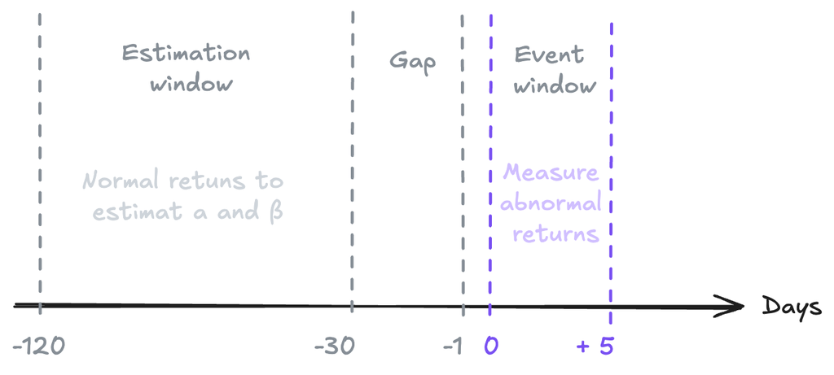

- **Estimation window** [−120, −30]: 91 trading days of “business as usual” returns to estimate the expected return model
- **Gap** [−29, −1]: Buffer to prevent event contamination from leaking into the estimation
- **Event window** [0, +5]: Six trading days over which we measure the market reaction
- Why [0, +5]? The market may take several days to fully incorporate complex information — but longer windows introduce more noise

## Event Study Methodology

### Step 2: The Market Model

The simplest expected return model:

$$R_{i,t} = \alpha_i + \beta_i R_{m,t} + \varepsilon_{i,t}$$

#### Components

- $R_{i,t}$: Stock return for firm $i$ on day $t$
- $R_{m,t}$: Market index return (e.g. DAX for German firms)
- $\alpha_i$: Firm-specific average return not explained by the market
- $\beta_i$: Sensitivity to market movements (market beta)
- $\varepsilon_{i,t}$: Idiosyncratic return — the “surprise”

#### Connection to L3

This is just **OLS**! We regress firm returns on market returns using only the estimation window.

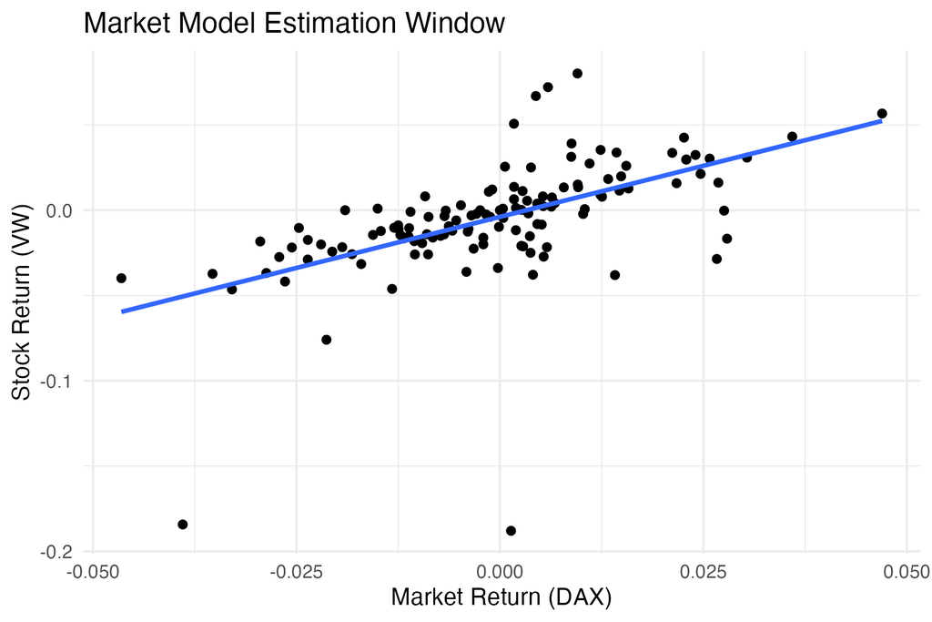

## Event Study Methodology

### Step 2: Estimation window — Fitting the model

#### What happens in the estimation window?

- We estimate $\hat{\alpha}_i$ and $\hat{\beta}_i$ using OLS on [−120, −30] only
- These parameters capture the firm’s “normal” relationship with the market
- The estimation window must be **before** the event to avoid contamination

#### Intuition

If VW stock typically moves 1.2% for every 1% move in the DAX ($\hat{\beta} = 1.2$), and earns an extra 0.01% per day on average ($\hat{\alpha} = 0.0001$), then on any given day we can predict what VW “should” have returned — absent any firm-specific news.

## Event Study Methodology

### Step 2: Choosing a benchmark model

| Model | Formula | Pros | Cons |
| --- | --- | --- | --- |
| Market Model | $R_i = \alpha + \beta R_m + \varepsilon$ | Simple, intuitive, widely used | Ignores size/value effects |
| CAPM | $R_i - R_f = \beta (R_m - R_f) + \varepsilon$ | Theoretical foundation | Constrains $\alpha = 0$ |
| **Fama–French 3-Factor** | $R_i - R_f = \alpha + \beta_{mkt}(R_m - R_f) + \beta_{smb}SMB + \beta_{hml}HML + \varepsilon$ | Controls for size and value | More parameters to estimate |

For short-window studies, the model choice typically does not matter much. We will verify this by comparing Market Model and FF3 results in A5.

## Event Study Methodology

### Step 3: The Fama–French 3-Factor Model

$$R_{i,t} - R_{f,t} = \alpha_i + \beta_{mkt}(R_{m,t} - R_{f,t}) + \beta_{smb}\, SMB_t + \beta_{hml}\, HML_t + \varepsilon_{i,t}$$

#### The two additional factors

- **SMB** (Small Minus Big): Return difference between small-cap and large-cap portfolios → captures size risk
- **HML** (High Minus Low): Return difference between high book-to-market (value) and low book-to-market (growth) stocks → captures value risk

#### Why bother?

If German automakers are systematically **large, value firms**, the Market Model may attribute some of their normal return to alpha when it is actually compensation for size and value exposure. FF3 controls for this — reducing potential misattribution bias in the abnormal return calculation.

See Fama and French (1993) for the original three-factor model.

## Event Study Methodology

### Step 4: Abnormal returns — The “surprise”

$$AR_{i,t} = R_{i,t} - \hat{E}[R_{i,t}]$$

- $R_{i,t}$: What the stock **actually** returned on day $t$
- $\hat{E}[R_{i,t}]$: What we **predicted** it would return, given the market
- $AR_{i,t}$: The **abnormal return** — the part unexplained by normal market movements

#### Sanity check

In the estimation window, the mean abnormal return should be approximately **zero** — because we estimated the model on that data. If $\bar{AR} \neq 0$ in the estimation window, something has gone wrong. This is the event study equivalent of checking OLS residuals.

## Event Study Methodology

### Step 4: Interpreting abnormal returns

#### What does AR mean?

- $AR > 0$: Stock did **better** than expected → positive surprise
- $AR < 0$: Stock did **worse** than expected → negative surprise
- $AR \approx 0$: Stock behaved as the model predicted → no news

#### Market Model AR

$$AR_{i,t}^{MM} = R_{i,t} - \hat{\alpha}_i - \hat{\beta}_i R_{m,t}$$

#### FF3 AR

$$AR_{i,t}^{FF3} = R_{i,t} - R_{f,t} - \hat{\alpha}_i - \hat{\beta}_{mkt}(R_{m,t} - R_{f,t})$$
$$- \hat{\beta}_{smb} SMB_t - \hat{\beta}_{hml} HML_t$$

## Event Study Methodology

### Step 5: Cumulative abnormal returns (CAR)

$$CAR_i[0, +5] = \sum_{t=0}^{5} AR_{i,t}$$

#### Why cumulate?

- Markets may take **several days** to fully digest complex information
- Day 0 captures the initial shock; days +1 to +5 capture revisions, analyst coverage, contagion effects, and information cascading through the market
- A single day’s AR might miss the full story — CAR captures the **total price impact**

**Connection to A3**

In Assignment 3, you used pre-calculated CARs as dependent variables in cross-sectional regressions. Now you understand where those numbers came from — and in A5 you will calculate them yourself.

## Event Study Methodology

### The classic event study plot

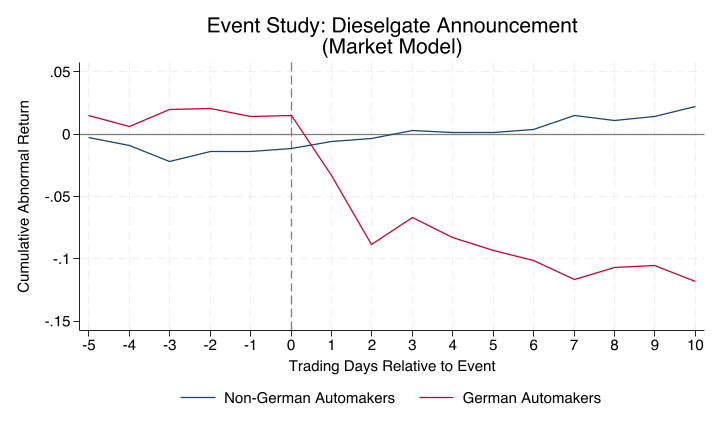

This is the visual equivalent of the DiD plot you saw in L4 — but at daily frequency with the “treatment” being the scandal announcement.

## Event Study Methodology

### Expected results from Dieselgate

#### Key findings (what you should find in A5)

- German automakers: **significant negative** CAR[0,+5]
- Non-German automakers: smaller or insignificant CARs
- VW hit hardest (direct responsibility), BMW and Mercedes affected by contagion / regulatory fears
- Market Model and FF3 results should be **similar** — confirming robustness

#### Model comparison

- If CARs from both models are **highly correlated** and close to the 45° line in a scatter plot → the expected return model is not driving your results
- This is a **robustness check** — demonstrating that your conclusions do not depend on the specific benchmark
- Differences, if any, reveal whether size/value factors are important for this particular sample

## Event Study Methodology

### Statistical testing

Once you have CARs, you need to test whether they are statistically significant:

#### Test 1: Is CAR ≠ 0?

- One-sample t-test: $H_0: \overline{CAR} = 0$
- Separately for German and non-German firms
- A rejection tells you the event had a **measurable price impact**

#### Test 2: Do groups differ?

- Two-sample t-test: $H_0: \overline{CAR}_{German} = \overline{CAR}_{non-German}$
- Tests whether German firms were hit **more** than controls
- This is the event study analog of the DiD treatment effect

**Small sample warning**

With only 3 German automakers (after dropping VW subsidiaries), t-tests have low statistical power. Interpret results in terms of **economic magnitude** alongside statistical significance.

## Event Study Methodology

### Cross-sectional analysis — “Who was hit hardest?”

After computing CARs, we can ask: **what firm characteristics predict larger (or smaller) reactions?**

$$CAR_i[0, +5] = \gamma_0 + \gamma_1 \text{German}_i + \gamma_2 \text{Size}_i + \gamma_3 \text{ROA}_i + \gamma_4 \text{Leverage}_i + u_i$$

- This is a **cross-sectional OLS** regression — connecting back to L3
- The dependent variable is the CAR you just calculated
- $\gamma_1$ captures the differential reaction for German firms
- $\gamma_2$ through $\gamma_4$ test whether firm characteristics (size, profitability, leverage) amplify or dampen the reaction

This is exactly what you did in A3 — but now you understand the full pipeline from raw returns to CARs to cross-sectional tests.

## Event Study Methodology

### Practical considerations and pitfalls

#### Common challenges

- **Thin trading**: Stocks that trade infrequently may have stale prices, biasing AR calculations
- **Event date ambiguity**: Was the “real” event the EPA notice on September 18, or the media coverage on September 19, or earlier rumours? Sensitivity analysis with different event dates helps
- **Overlapping events**: If another major announcement coincides with the event, the AR will capture both
- **Small samples**: With few treated firms, statistical power is low and outliers are influential
- **Event window length**: Shorter windows are cleaner but may miss delayed reactions; longer windows introduce noise

For a comprehensive treatment, see MacKinlay (1997).

## Event Study Methodology

### Summary of event studies

| Aspect | Key point |
| --- | --- |
| **When to use** | Market reactions to specific, well-dated events |
| **Key assumption** | Market efficiency — prices reflect public information quickly |
| **Identification** | Expected return model provides the counterfactual |
| **Strengths** | Precise timing, clean identification in short windows |
| **Limitations** | Single events, small N, model dependence for longer horizons |
| **In A5** | You implement the full pipeline on Dieselgate data |

# New Frontiers: Event Studies Meet Causal Inference

## New Frontiers

### Reframing event studies as causal inference

The classic event study asks: *“What would this stock have returned absent the event?”*

That is fundamentally a **counterfactual question** — the same question DiD asks, just at daily frequency. Goldsmith-Pinkham and Lyu (2025) make this connection explicit:

> The traditional abnormal return $AR_{i,t} = R_{i,t} - \hat{E}[R_{i,t}]$ is really an estimate of the **average treatment effect on the treated** — where the “treatment” is the event and the “counterfactual” comes from the factor model.

**Same revolution, different setting**

Just as Baker et al. (2022) showed that standard TWFE can go wrong in staggered DiD, Goldsmith-Pinkham and Lyu (2025) show that standard abnormal return estimators can be biased when the factor model is wrong. The causal inference revolution is reaching event studies.

## New Frontiers

### When does the benchmark model matter?

Two dimensions determine how much trouble you face:

|  | Short-run (days) | Long-run (months/years) |
| --- | --- | --- |
| **Many events, random timing** | Model choice barely matters ✅ | Model choice matters ⚠️ |
| **Single event** | It depends ⚠️ | Almost always biased ❌ |

#### The intuition

- Daily factor premiums are tiny (~0.02%). Over a 5-day window, misspecification error is negligible
- But compound that over 250 trading days → up to 5 percentage points of bias
- With many randomly timed events, factor *realizations* average out. With a single event, you are exposed to whatever the factors happened to do on that specific day
- Dieselgate is a single event — we should be aware of this limitation, even though our short window provides protection

## New Frontiers

### When it goes wrong — A concrete example

Acemoglu et al. (2016) study firms connected to Timothy Geithner around his nomination as Treasury Secretary (November 21, 2008):

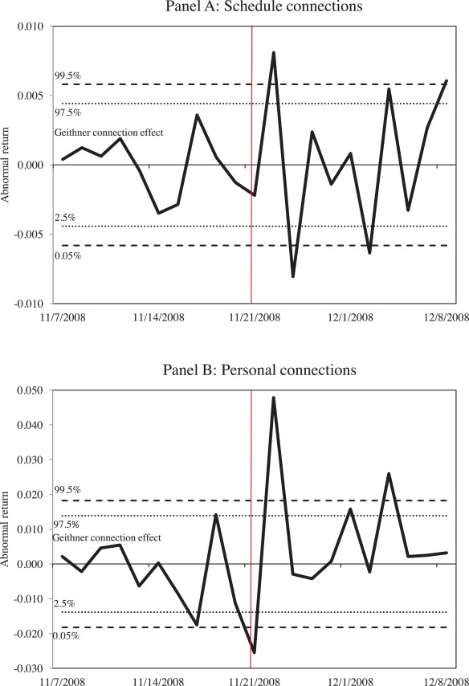

## New Frontiers

### When it goes wrong — A concrete example

Acemoglu et al. (2016) study firms connected to Timothy Geithner around his nomination as Treasury Secretary (November 21, 2008):

#### The setup

- **Single event**, during the peak of the financial crisis
- **Non-random timing** — event happened when factor realizations were extreme
- **Short horizon** — but unusual market conditions

#### The finding

- Standard methods (Market Model, FF3) → significant positive effects for connected firms
- Synthetic control / gsynth methods → effects **shrink dramatically toward zero**
- Why? The event coincided with extreme factor realizations. Standard models attribute part of the factor movement to the treatment effect

## New Frontiers

### When it goes wrong — A concrete example

Acemoglu et al. (2016) study firms connected to Timothy Geithner around his nomination as Treasury Secretary (November 21, 2008):

#### The setup

- **Single event**, during the peak of the financial crisis
- **Non-random timing** — event happened when factor realizations were extreme
- **Short horizon** — but unusual market conditions

#### The lesson

- with a single event in unusual market conditions, your factor model is doing heavy lifting
- Robustness across models (like comparing Market Model vs. FF3) helps, but it is not a complete solution

## New Frontiers

### Alternative counterfactual approaches

Instead of assuming you know the right factor model, let the **data** construct the counterfactual:

| Approach | Key idea | Connection |
| --- | --- | --- |
| **Synthetic control** | Weighted portfolio of control firms that matches pre-event returns | Same as Abadie’s SCM from policy evaluation |
| **GSynth / PCA regression** | Data-driven factor structure estimated from the pre-event period | Lets the data find the factors instead of assuming them |
| **Synthetic DiD** | Combines synthetic control weighting with DiD structure | Bridges the two literatures |

For details see Goldsmith-Pinkham and Lyu (2025).

## New Frontiers

### Takeaway for your thesis

**Practical guidance**

- **Short-run, many events, random timing** → Market Model / FF3 results are fine. Model choice barely matters (see Shleifer 1986)
- **Short-run, single event** (like Dieselgate) → Be aware that factor realizations add noise. Comparing multiple models (as you do in A5) is a good robustness check
- **Long-run event studies** → Seriously consider synthetic control or GSynth
- **General rule**: If your Market Model and FF3 CARs agree closely, that is reassuring. If they disagree, dig into why

The good news: A5 uses a **short event window** [0,+5] and compares **two benchmark models**. If both tell the same story, your results are robust to the concerns raised by this new literature.

# Fama–MacBeth Regression

## Fama–MacBeth Regression

### From event reactions to systematic patterns

Event studies ask: *“Did this specific event move stock prices?”*

A different question: *“Do certain firm characteristics systematically predict returns across time?”*

#### Examples

- Does firm size predict cross-sectional return differences?
- Is there a value premium — do high book-to-market firms outperform?
- See Feng et al. (2020) for the factor zoo
- openassetpricing.com by Chen and Zimmermann (2022)

#### Why a new method?

- These are **repeated cross-sectional** questions, not event-specific
- We need data across **many time periods** and **many firms**
- Standard pooled OLS has a serious problem…

## Fama–MacBeth Regression

### The problem with pooled OLS

#### Cross-sectional correlation of residuals

When you pool all firm-month observations and run OLS, you implicitly assume residuals are independent across firms within the same period. But…

- Firms are hit by **common shocks** (recessions, market crashes, policy changes)
- On a bad day, *most* firms have negative residuals simultaneously
- This means residuals within the same time period are **correlated**

**The consequence**

Pooled OLS dramatically **understates standard errors**, leading to inflated t-statistics and false conclusions about significance. This is similar to the Moulton problem from L4 — but the correlation is **cross-sectional** (across firms in the same period) rather than within-group over time.

## Fama–MacBeth Regression

### The Fama–MacBeth idea

Fama and MacBeth (1973) proposed an elegant two-step solution:

#### Step 1: For each month t, run a cross-sectional regression

Collect T slope coefficients $\hat{\gamma}_{1,1}, \hat{\gamma}_{1,2}, \ldots, \hat{\gamma}_{1,T}$

#### Step 2: Average the T coefficients and use their time-series variation for inference

$\bar{\gamma}_1 = \frac{1}{T} \sum_{t=1}^{T} \hat{\gamma}_{1,t} \quad \text{and} \quad SE(\bar{\gamma}_1) = \frac{s(\hat{\gamma}_{1,t})}{\sqrt{T}}$

**The key insight**

Each cross-sectional regression produces **one** estimate per period. By treating these as a time series, you automatically account for cross-sectional correlation — because each $\hat{\gamma}_{1,t}$ already incorporates whatever common shock happened in period $t$.

## Fama–MacBeth Regression

### Step 1: Cross-sectional regressions

For each time period $t$ (e.g. each month):

$$R_{i,t} = \gamma_{0,t} + \gamma_{1,t}\, X_{i,t-1} + \varepsilon_{i,t}$$

#### What this looks like

- Each month is a separate cross-sectional regression
- The dependent variable is the return for firm $i$ in month $t$
- The independent variable $X_{i,t-1}$ is a firm characteristic **lagged by one period** to avoid look-ahead bias
- Each regression produces its own slope $\hat{\gamma}_{1,t}$

#### Visual intuition

Imagine 3–4 scatter plots side by side, each showing one month’s cross-section: firm returns on the y-axis vs. a characteristic (e.g. ESG score) on the x-axis. Each scatter plot has its own fitted line. The slopes vary from month to month — some steep, some flat, some negative. FM collects all these slopes and asks: **on average, is the slope positive?**

## Fama–MacBeth Regression

### Step 2: Time-series average

$$\bar{\gamma}_1 = \frac{1}{T} \sum_{t=1}^{T} \hat{\gamma}_{1,t}$$

The average slope across all periods is our estimate of the **systematic relationship** between the characteristic and returns — the risk premium, if you are thinking in asset pricing terms.

## Fama–MacBeth Regression

### Step 3: Standard errors

$$SE(\bar{\gamma}_1) = \frac{s(\hat{\gamma}_{1,t})}{\sqrt{T}}$$

where $s(\hat{\gamma}_{1,t})$ is the standard deviation of the $T$ estimated slopes.

**Why this solves the problem**

Pooled OLS treats each firm-month as independent → too many “observations.” FM recognizes that there are only $T$ independent cross-sections. The time-series variation in $\hat{\gamma}_{1,t}$ reflects the **true uncertainty** about the average relationship. If the slope is stable over time, SE is small; if it bounces around, SE is large.

## Fama–MacBeth Regression

#### What the distribution tells you

- **Slopes tightly clustered around a positive value** → strong, stable evidence that the characteristic predicts returns
- **Slopes widely dispersed around zero** → no reliable relationship; sometimes positive, sometimes negative
- **Slopes with a clear positive mean but large variance** → the relationship exists on average but is noisy period-by-period

This distribution is the *core diagnostic* of Fama–MacBeth. It shows you not just the average effect, but how consistent it is over time.

## Fama–MacBeth Regression

### Comparison: FM vs. pooled OLS vs. panel FE

| Aspect | Pooled OLS | Panel FE (L4) | Fama–MacBeth |
| --- | --- | --- | --- |
| **Problem addressed** | — | Time-invariant confounders | Cross-sectional correlation of residuals |
| **How** | Single regression on all data | Entity & time fixed effects | Repeated cross-sectional regressions |
| **SE adjustment** | None (or robust/clustered) | Cluster by entity or time | Time-series variation of coefficients |
| **Typical use** | Baseline specification | Corporate finance panels | Asset pricing, return predictability |
| **Assumes** | Independence | Parallel trends, no time-varying confounders | Stable cross-sectional relationship |
| **Risk** | Overstated significance | Absorbs too much variation | Imprecise first-stage estimates (EIV) |

#### When to use FM vs. clustered SE?

Petersen (2008) shows that FM and **clustering by time** address the same problem (cross-sectional correlation). In practice, double-clustering (by firm *and* time) is a modern alternative. FM remains standard for asset pricing tests because of its interpretability: the distribution of $\hat{\gamma}_{1,t}$ values is informative in its own right.

## Fama–MacBeth Regression

### Applications in published research

Fama–MacBeth is everywhere in asset pricing and corporate finance:

- **Original CAPM tests**: Fama and MacBeth (1973) tested whether market beta explains cross-sectional return variation
- **Fama–French factor tests**: Do SMB and HML factors carry a risk premium?
- **ESG and returns**: Does environmental or social performance predict returns?
- **Liquidity premiums**: Do less-liquid stocks earn higher returns?
- **Anomaly research**: Size, value, momentum, profitability, investment — nearly all tested via FM

If you read a finance paper that reports “Fama–MacBeth regressions,” you now know exactly what the authors did and why.

## Fama–MacBeth Regression

### Limitations

- **Errors-in-variables (EIV)**: The first-stage coefficients $\hat{\gamma}_{1,t}$ are estimated with error, which attenuates the second-stage average toward zero. The **Shanken correction** adjusts for this, but adds complexity, see Kim (1995) and Shanken (1992).
- **Persistence in characteristics**: FM assumes cross-sections are relatively independent over time. If firm characteristics are highly persistent (e.g. firm size barely changes month-to-month), FM may underperform double-clustered SE approaches
- **Balanced panel preference**: FM works best when each cross-section has a similar set of firms. If the firm universe changes dramatically over time, the $\hat{\gamma}_{1,t}$ estimates may not be comparable
- **Modern alternatives**: Double-clustered standard errors (Petersen 2008) address the same problem and are easier to implement in standard software

## Fama–MacBeth Regression

### Summary

[output not shown]

# Synthesis

## Synthesis

### The complete methods toolkit

| Lecture | Method | Identifies | Data structure | Key assumption |
| --- | --- | --- | --- | --- |
| L3 | OLS + controls | Cross-sectional relationships | Cross-section | No omitted variables (selection on observables) |
| L4 | DiD / Panel FE | Causal effect of treatment | Panel | Parallel trends |
| L5 | Event study | Market reaction to specific events | Daily panel | Market efficiency + correct factor model |
| L5 | Fama–MacBeth | Systematic return predictability | Repeated cross-sections | Cross-sections are independent draws |

Each method trades off different assumptions. The art of empirical finance is choosing the method whose assumptions are **most credible** for your specific research question and data.

## Synthesis

### Standard errors: A unifying thread

The standard error story has been building across the course:

- **L3**: Heteroskedasticity-robust SE → solves non-constant variance
- **L4**: Cluster-robust SE → handles within-group correlation (Moulton problem)
- **L5**: Fama–MacBeth SE → handles cross-sectional correlation of residuals

All three address the same fundamental issue: **when residuals are not independent, naive standard errors are too small**. The solution is always to match the inference method to the correlation structure of the data.

**The common thread**

The choice of standard error is not a technicality, it is a statement about **what you believe is independent** in your data. Getting it wrong can flip your conclusions from significant to insignificant (or vice versa).

## Synthesis

### Connection to A5

Assignment 5 asks you to:

1. Load daily stock return data for auto firms
2. Drop VW subsidiaries to avoid mechanical linkages
3. Define estimation [−120, −30] and event [0, +5] windows
4. Estimate **Market Model** and **Fama–French 3-Factor** expected returns
5. Calculate abnormal returns (AR) and cumulative abnormal returns (CAR)
6. Create the classic event study visualization
7. Conduct cross-sectional tests on CARs

This is the full event study pipeline from raw data to publishable results. Everything from today’s lecture maps directly onto specific assignment tasks.

## Synthesis

### Connection to your thesis

Both methods from today are staples of finance research:

- **Event studies** appear in papers on M&A announcements, earnings surprises, regulatory changes, CEO turnovers, patent issuances, and many more corporate events
- **Fama–MacBeth** is the standard approach for testing asset pricing models and cross-sectional return predictability

**For your replication project**

Understanding the mechanics, assumptions, and limitations of the applied methods puts you in a strong position to critically evaluate and extend the original analysis.

## Synthesis

### Looking ahead — L6: Replication Workshop

In the final lecture, we bring everything together:

- How to read and replicate a published paper, seagway through Huck (2024) before next lecture
- Connecting methods (OLS, DiD, event studies, FM) to research designs
- Common pitfalls in replication work
- How to extend a replication for your thesis

**Key message from this course**

The methods are tools, not ends in themselves. The value is in understanding **when** each tool is appropriate, **what** it assumes, and **how** to interpret the results in the context of a real research question.

Thank You for Your Attention!

See You in the Final Lecture!

## References

Acemoglu, Daron, Simon Johnson, Amir Kermani, James Kwak, and Todd Mitton. 2016. “The Value of Connections in Turbulent Times: Evidence from the United States.” *Journal of Financial Economics* 121 (2): 368–91.

Baker, Andrew C, David F Larcker, and Charles CY Wang. 2022. “How Much Should We Trust Staggered Difference-in-Differences Estimates?” *Journal of Financial Economics* 144 (2): 370–95.

Chen, Andrew Y., and Tom Zimmermann. 2022. “Open Source Cross-Sectional Asset Pricing.” *Critical Finance Review* 27 (2): 207–64.

Fama, Eugene F. 1970. “Efficient Capital Markets: A Review of Theory and Empirical Work.” *The Journal of Finance* 25 (2): 383–417.

Fama, Eugene F, and Kenneth R French. 1993. “Common Risk Factors in the Returns on Stocks and Bonds.” *Journal of Financial Economics* 33 (1): 3–56.

Fama, Eugene F, and James D MacBeth. 1973. “Risk, Return, and Equilibrium: Empirical Tests.” *Journal of Political Economy* 81 (3): 607–36.

Feng, Guanhao, Stefano Giglio, and Dacheng Xiu. 2020. “Taming the Factor Zoo: A Test of New Factors.” *The Journal of Finance* 75 (3): 1327–70.

Goldsmith-Pinkham, Paul, and Tianshu Lyu. 2025. “Causal Inference in Financial Event Studies.” https://arxiv.org/abs/2511.15123.

Huck, John R. 2024. “The Psychological Externalities of Investing: Evidence from Stock Returns and Crime.” *The Review of Financial Studies* 37 (7): 2273–314.

Kim, Dongcheol. 1995. “The Errors in the Variables Problem in the Cross-Section of Expected Stock Returns.” *The Journal of Finance* 50 (5): 1605–34.

Kolari, James W, and Seppo Pynnönen. 2010. “Event Study Testing with Cross-Sectional Correlation of Abnormal Returns.” *The Review of Financial Studies* 23 (11): 3996–4025.

MacKinlay, A Craig. 1997. “Event Studies in Economics and Finance.” *Journal of Economic Literature* 35 (1): 13–39.

Petersen, Mitchell A. 2008. “Estimating Standard Errors in Finance Panel Data Sets: Comparing Approaches.” *The Review of Financial Studies* 22 (1): 435–80. https://doi.org/10.1093/rfs/hhn053.

Shanken, Jay. 1992. “On the Estimation of Beta-Pricing Models.” *The Review of Financial Studies* 5 (1): 1–33.

Shleifer, Andrei. 1986. “Do Demand Curves for Stocks Slope Down?” *The Journal of Finance* 41 (3): 579–90.

# Appendix

## Appendix

### MacKinlay (1997) — The classic event study reference

MacKinlay (1997) established the modern event study framework:

- Formalized the estimation window / event window structure
- Showed that the Market Model dominates simpler approaches (mean-adjusted, market-adjusted)
- Provided test statistics for single-firm and multi-firm event studies
- Discussed parametric and non-parametric tests

This paper remains the default citation for event study methodology. Nearly every event study paper begins with a sentence like: *“We follow the standard event study methodology of MacKinlay (1997).”*

## Appendix

### Fama & French (1993) — Factor construction

#### How SMB and HML are constructed

- **SMB**: Sort all stocks by market capitalization into two groups (small, big). SMB = return of small portfolio − return of big portfolio
- **HML**: Sort all stocks by book-to-market ratio into three groups (low, medium, high). HML = return of high B/M portfolio − return of low B/M portfolio
- Both factors are rebalanced annually and returns are computed daily or monthly

#### Why these factors?

Fama and French (1993) documented that size and value explain a large share of cross-sectional return variation that CAPM beta alone cannot. Whether these reflect **risk** or **mispricing** remains debated — but the empirical regularity is well-established.

## Appendix

### Petersen (2008) — Choosing the right standard errors

Petersen (2008) provides a decision framework:

| Correlation structure | Solution |
| --- | --- |
| **Firm effect** (residuals correlated within firm over time) | Cluster by firm |
| **Time effect** (residuals correlated across firms within period) | Cluster by time, or Fama–MacBeth |
| **Both** | Double-cluster by firm AND time |

Key finding: Fama–MacBeth and clustering by time produce **similar** standard errors when the number of time periods is large. Double-clustering is more general and handles both dimensions simultaneously.

## Appendix

### Event study cross-sectional correlation

Kolari and Pynnönen (2010) address a subtle issue: even in short-window event studies, abnormal returns may be **cross-sectionally correlated** when the event affects multiple firms simultaneously (as in Dieselgate).

Standard event study tests assume independence across firms. When this fails:

- Aggregate test statistics are **inflated**
- The adjusted BMP test accounts for cross-sectional correlation in ARs
- Alternative: bootstrap methods that resample clusters of firms

This matters for Dieselgate because all German automakers are hit by the same event on the same day — their ARs are not independent draws.

## Appendix

#### Three empirical examples

1. **Geithner connections** (single event, non-random timing): Standard methods overstate effects; synthetic control finds near-zero effects
2. **S&P 500 index inclusion** (many events, random timing): All methods agree in the short run — model choice does not matter
3. **M&A acquirer returns** (many events, quasi-random): Short-run effects similar across methods; long-run effects diverge substantially

#### Key takeaways

- Short-run + random timing → classical methods work well
- Single event OR long horizon → factor model misspecification can seriously bias results
- Synthetic control and GSynth are robust alternatives, especially for long-horizon studies
- The bias compounds over time: a daily misspecification of 0.02% becomes 5% over a year